# Ordinal Logistic Regression with the Big Five

Does Neuroticism predict responses to ‘Do things in a half-way manner’?

## 0.1 Question and Predictions

The BFI data contain 25 personality items from 2,800 people, with five items measuring each of the Big Five personality traits. Each item is answered on a 6-point scale ranging from *Very inaccurate* to *Very accurate*.

The selected outcome is **C4, “Do things in a half-way manner,”** an item measuring Conscientiousness. The predictor is the **Neuroticism subscale score**, calculated as the mean of N1 to N5.

I predict that higher Neuroticism scores will be associated with higher responses to C4. Individuals with higher Neuroticism may experience greater emotional instability, which could be associated with difficulty maintaining consistent task completion. Because C4 is reverse-keyed, higher responses indicate lower Conscientiousness.

## 0.2 Load and inspect the data

```r
bfi_data <- read_excel("bfi.xlsx")

# Identify the 25 Big Five personality items
item_vars <- grep("^[ACENO][1-5]$", names(bfi_data), value = TRUE)

# Check that all 25 items are available
stopifnot(length(item_vars) == 25)

# Convert personality items to numeric
bfi_data[item_vars] <- lapply(
  bfi_data[item_vars],
  as.integer
)

# Inspect the dataset
str(bfi_data)
```

```
tibble [2,800 × 29] (S3: tbl_df/tbl/data.frame)
 $ ...1     : num [1:2800] 61617 61618 61620 61621 61622 ...
 $ A1       : int [1:2800] 2 2 5 4 2 6 2 4 4 2 ...
 $ A2       : int [1:2800] 4 4 4 4 3 6 5 3 3 5 ...
 $ A3       : int [1:2800] 3 5 5 6 3 5 5 1 6 6 ...
 $ A4       : int [1:2800] 4 2 4 5 4 6 3 5 3 6 ...
 $ A5       : int [1:2800] 4 5 4 5 5 5 5 1 3 5 ...
 $ C1       : int [1:2800] 2 5 4 4 4 6 5 3 6 6 ...
 $ C2       : int [1:2800] 3 4 5 4 4 6 4 2 6 5 ...
 $ C3       : int [1:2800] 3 4 4 3 5 6 4 4 3 6 ...
 $ C4       : int [1:2800] 4 3 2 5 3 1 2 2 4 2 ...
 $ C5       : int [1:2800] 4 4 5 5 2 3 3 4 5 1 ...
 $ E1       : int [1:2800] 3 1 2 5 2 2 4 3 5 2 ...
 $ E2       : int [1:2800] 3 1 4 3 2 1 3 6 3 2 ...
 $ E3       : int [1:2800] 3 6 4 4 5 6 4 4 NA 4 ...
 $ E4       : int [1:2800] 4 4 4 4 4 5 5 2 4 5 ...
 $ E5       : int [1:2800] 4 3 5 4 5 6 5 1 3 5 ...
 $ N1       : int [1:2800] 3 3 4 2 2 3 1 6 5 5 ...
 $ N2       : int [1:2800] 4 3 5 5 3 5 2 3 5 5 ...
 $ N3       : int [1:2800] 2 3 4 2 4 2 2 2 2 5 ...
 $ N4       : int [1:2800] 2 5 2 4 4 2 1 6 3 2 ...
 $ N5       : int [1:2800] 3 5 3 1 3 3 1 4 3 4 ...
 $ O1       : int [1:2800] 3 4 4 3 3 4 5 3 6 5 ...
 $ O2       : int [1:2800] 6 2 2 3 3 3 2 2 6 1 ...
 $ O3       : int [1:2800] 3 4 5 4 4 5 5 4 6 5 ...
 $ O4       : int [1:2800] 4 3 5 3 3 6 6 5 6 5 ...
 $ O5       : int [1:2800] 3 3 2 5 3 1 1 3 1 2 ...
 $ gender   : num [1:2800] 1 2 2 2 1 2 1 1 1 2 ...
 $ education: chr [1:2800] "NA" "NA" "NA" "NA" ...
 $ age      : num [1:2800] 16 18 17 17 17 21 18 19 19 17 ...
```

```r
head(bfi_data)
```

```
# A tibble: 6 × 29
   ...1    A1    A2    A3    A4    A5    C1    C2    C3    C4    C5    E1    E2
  <dbl> <int> <int> <int> <int> <int> <int> <int> <int> <int> <int> <int> <int>
1 61617     2     4     3     4     4     2     3     3     4     4     3     3
2 61618     2     4     5     2     5     5     4     4     3     4     1     1
3 61620     5     4     5     4     4     4     5     4     2     5     2     4
4 61621     4     4     6     5     5     4     4     3     5     5     5     3
5 61622     2     3     3     4     5     4     4     5     3     2     2     2
6 61623     6     6     5     6     5     6     6     6     1     3     2     1
# ℹ 16 more variables: E3 <int>, E4 <int>, E5 <int>, N1 <int>, N2 <int>,
#   N3 <int>, N4 <int>, N5 <int>, O1 <int>, O2 <int>, O3 <int>, O4 <int>,
#   O5 <int>, gender <dbl>, education <chr>, age <dbl>
```

## 0.3 Data preparation

### 0.3.1 Define response labels

```r
labels <- c(
  "Very inaccurate",
  "Moderately inaccurate",
  "Slightly inaccurate",
  "Slightly accurate",
  "Moderately accurate",
  "Very accurate"
)
```

### 0.3.2 Score the Big Five subscales

```r
keys <- list(
  Agreeableness = c("-A1", "A2", "A3", "A4", "A5"),
  Conscientiousness = c("C1", "C2", "C3", "-C4", "-C5"),
  Extraversion = c("-E1", "-E2", "E3", "E4", "E5"),
  Neuroticism = c("N1", "N2", "N3", "N4", "N5"),
  Openness = c("O1", "-O2", "O3", "O4", "-O5")
)

scores_obj <- scoreItems(
  keys,
  bfi_data,
  totals = FALSE,
  min = 1,
  max = 6
)

# Extract the five personality scores
scores <- as.data.frame(scores_obj$scores)

# Add personality scores to the original dataset
bfi_data <- bind_cols(bfi_data, scores)

# Inspect the calculated scores
head(scores)
```

```
  Agreeableness Conscientiousness Extraversion Neuroticism Openness
1           4.0               2.8          3.8         2.8      3.0
2           4.2               4.0          5.0         3.8      4.0
3           3.8               4.0          4.2         3.6      4.8
4           4.6               3.0          3.6         2.8      3.2
5           4.0               4.4          4.8         3.2      3.6
6           4.6               5.6          5.6         3.0      5.0
```

### 0.3.3 Calculate the dominant personality trait

```r
trait_scores <- scores |>
  select(
    Agreeableness,
    Conscientiousness,
    Extraversion,
    Neuroticism,
    Openness
  )

bfi_data$highest <- factor(
  names(trait_scores)[
    max.col(
      as.matrix(trait_scores),
      ties.method = "first"
    )
  ],
  levels = names(trait_scores)
)

# Check dominant trait frequencies
table(bfi_data$highest)
```

```
    Agreeableness Conscientiousness      Extraversion       Neuroticism
             1137               459               347               216
         Openness
              641
```

### 0.3.4 Prepare the analysis dataset

```r
# Convert C4 into an ordered factor
bfi_data$C4 <- ordered(
  bfi_data$C4,
  levels = 1:6,
  labels = labels
)

# Create the analysis dataset
data <- bfi_data |>
  select(C4, Neuroticism) |>
  drop_na()

# Calculate mean Neuroticism
neuroticism_bar <- mean(data$Neuroticism)

# Centre Neuroticism
data <- data |>
  mutate(
    neuroticism_c = Neuroticism - neuroticism_bar
  )

# Check the analysis dataset
str(data)
```

```
tibble [2,774 × 3] (S3: tbl_df/tbl/data.frame)
 $ C4           : Ord.factor w/ 6 levels "Very inaccurate"<..: 4 3 2 5 3 1 2 2 4 2 ...
 $ Neuroticism  : num [1:2774] 2.8 3.8 3.6 2.8 3.2 3 1.4 4.2 3.6 4.2 ...
 $ neuroticism_c: num [1:2774] -0.361 0.639 0.439 -0.361 0.039 ...
```

```r
summary(data)
```

```
                     C4       Neuroticism    neuroticism_c
 Very inaccurate      :769   Min.   :1.000   Min.   :-2.161
 Moderately inaccurate:794   1st Qu.:2.200   1st Qu.:-0.961
 Slightly inaccurate  :472   Median :3.000   Median :-0.161
 Slightly accurate    :448   Mean   :3.161   Mean   : 0.000
 Moderately accurate  :228   3rd Qu.:4.000   3rd Qu.: 0.839
 Very accurate        : 63   Max.   :6.000   Max.   : 2.839
```

### 0.3.5 Check the variables

```r
names(bfi_data)
```

```
 [1] "...1"              "A1"                "A2"
 [4] "A3"                "A4"                "A5"
 [7] "C1"                "C2"                "C3"
[10] "C4"                "C5"                "E1"
[13] "E2"                "E3"                "E4"
[16] "E5"                "N1"                "N2"
[19] "N3"                "N4"                "N5"
[22] "O1"                "O2"                "O3"
[25] "O4"                "O5"                "gender"
[28] "education"         "age"               "Agreeableness"
[31] "Conscientiousness" "Extraversion"      "Neuroticism"
[34] "Openness"          "highest"
```

```r
head(bfi_data$Neuroticism)
```

```
[1] 2.8 3.8 3.6 2.8 3.2 3.0
```

```r
head(bfi_data$C4)
```

```
[1] Slightly accurate     Slightly inaccurate   Moderately inaccurate
[4] Moderately accurate   Slightly inaccurate   Very inaccurate
6 Levels: Very inaccurate < Moderately inaccurate < ... < Very accurate
```

```r
head(data$neuroticism_c)
```

```
[1] -0.36099495  0.63900505  0.43900505 -0.36099495  0.03900505 -0.16099495
```

```r
labels
```

```
[1] "Very inaccurate"       "Moderately inaccurate" "Slightly inaccurate"
[4] "Slightly accurate"     "Moderately accurate"   "Very accurate"
```

# 1 1. Look at the outcomes first

## 1.1 The ordered outcome

Check that no category is empty or very sparse.

```
# A tibble: 6 × 3
  C4                        n      p
  <ord>                 <int>  <dbl>
1 Very inaccurate         769 0.277
2 Moderately inaccurate   794 0.286
3 Slightly inaccurate     472 0.170
4 Slightly accurate       448 0.161
5 Moderately accurate     228 0.0822
6 Very accurate            63 0.0227
```

Every category should be checked for sufficient responses before fitting the ordinal logistic regression model. The smallest category contains 63 responses.

This can be displayed graphically:

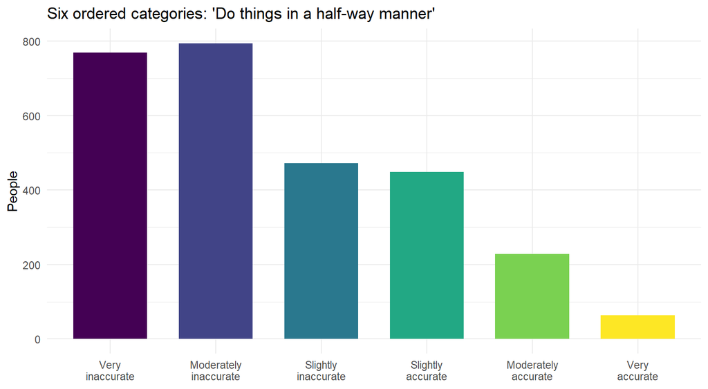

## 1.2 How the predictor relates to the responses

We can also visualize how the predictor relates to the responses, seeing how each person’s Neuroticism score relates to their C4 response. Because many people have the same Neuroticism score and the same C4 response, we use *`geom_jitter`* to spread out the overlapping points.

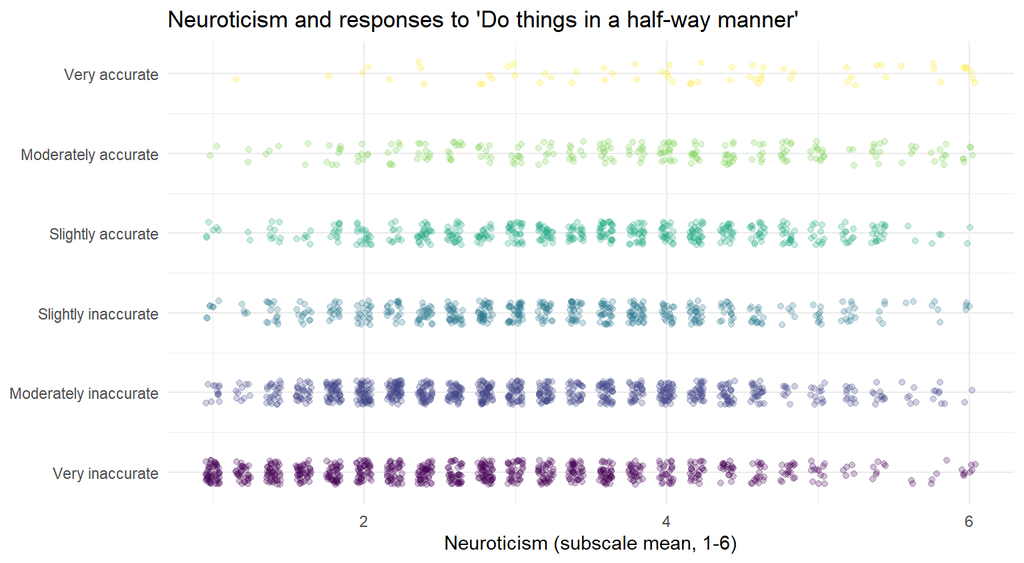

The outcome takes only six values. A good ordinal logistic regression model should predict a probability for each of those six ordered response categories, rather than a specific decimal average that is not an available response option.

## 1.3 An unordered outcome

Each person’s **dominant trait** (their highest of the five subscale scores) is a set of categories with **no built-in order**. Being highest on Openness is not “more” than being highest on Agreeableness. An outcome like this requires a baseline-category (multinomial) model, such as `nnet::multinom()`, rather than `clm()`.

Here we can see how many people have each trait as their highest.

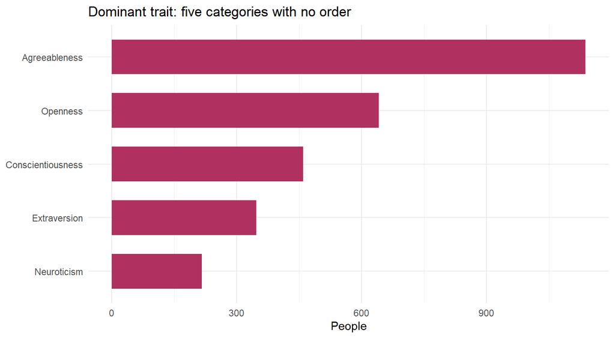

# 2 2. Cumulative probabilities

A cumulative probability is the probability of responding with a specific response category (*j*) or lower. With six ordered categories, there are five cumulative probabilities to model. This is because cumulative probabilities represent the probability of selecting a particular response option or any response option below it. For example, the cumulative probability at the third category includes responses in categories 1, 2, and 3. The cumulative probability of the sixth category is 100%, so only five cumulative probabilities provide finite cumulative odds and log-odds.

| Category in C4 (j) | n | P(Y = j) | P(Y ≤ j) | Odds of ≤ j | Log-odds of ≤ j |
| --- | --- | --- | --- | --- | --- |
| Very inaccurate | 769 | 0.277 | 0.277 | 0.38 | −0.96 |
| Moderately inaccurate | 794 | 0.286 | 0.563 | 1.29 | 0.26 |
| Slightly inaccurate | 472 | 0.170 | 0.734 | 2.75 | 1.01 |
| Slightly accurate | 448 | 0.161 | 0.895 | 8.53 | 2.14 |
| Moderately accurate | 228 | 0.082 | 0.977 | 43.03 | 3.76 |
| Very accurate | 63 | 0.023 | 1.000 | — | — |

Each cumulative probability splits the response scale into two groups: responses at or below category *j* and responses above category *j*. Each comparison can be treated as a binary outcome and modeled using the logit link function. The ordinal logistic regression model estimates all five cumulative comparisons simultaneously while accounting for the natural ordering of the six response categories.

# 3 3. The model with a centred predictor

We centred the Neuroticism subscale score so that the thresholds describe a person with average Neuroticism (3.160995), rather than a person with a score of 0 on the original 1–6 scale. Centring changes the thresholds but does not change the slope.

When reading the `summary()` output, the **thresholds** represent the boundaries between adjacent response categories. The **coefficient** represents the slope, indicating the association between Neuroticism and the cumulative log-odds of responding at or below each threshold.

```
formula: C4 ~ neuroticism_c
data:    data

 link  threshold nobs logLik   AIC     niter max.grad cond.H
 logit flexible  2774 -4331.67 8675.34 5(0)  1.60e-07 3.7e+01

Coefficients:
              Estimate Std. Error z value Pr(>|z|)
neuroticism_c  0.44008    0.03021   14.57   <2e-16 ***
---
Signif. codes:  0 '***' 0.001 '**' 0.01 '*' 0.05 '.' 0.1 ' ' 1

Threshold coefficients:
                                          Estimate Std. Error z value
Very inaccurate|Moderately inaccurate     -1.02464    0.04367  -23.46
Moderately inaccurate|Slightly inaccurate  0.25486    0.03915    6.51
Slightly inaccurate|Slightly accurate      1.05540    0.04395   24.01
Slightly accurate|Moderately accurate      2.23565    0.06321   35.37
Moderately accurate|Very accurate          3.88659    0.12835   30.28
```

```
    Very inaccurate|Moderately inaccurate
                               -1.0246364
Moderately inaccurate|Slightly inaccurate
                                0.2548571
    Slightly inaccurate|Slightly accurate
                                1.0553961
    Slightly accurate|Moderately accurate
                                2.2356532
        Moderately accurate|Very accurate
                                3.8865850
                            neuroticism_c
                                0.4400842
```

The estimated slope is β = 0.44. This coefficient represents the association between Neuroticism and the cumulative log-odds of responding at or below each threshold. A positive slope indicates that higher Neuroticism is associated with greater odds of selecting higher response categories, whereas a negative slope indicates greater odds of selecting lower response categories.

## 3.1 What the centred thresholds mean

| Category | Threshold above category | P(Y ≤ j) | P(Y = j) |
| --- | --- | --- | --- |
| Very inaccurate | −1.02 | 0.26 | 0.26 |
| Moderately inaccurate | 0.25 | 0.56 | 0.30 |
| Slightly inaccurate | 1.06 | 0.74 | 0.18 |
| Slightly accurate | 2.24 | 0.90 | 0.16 |
| Moderately accurate | 3.89 | 0.98 | 0.08 |
| Very accurate | — | 1.00 | 0.02 |

Apply `plogis()` to each threshold to obtain the cumulative probabilities, then calculate the differences between consecutive cumulative probabilities to obtain the probability of each individual response category. For a person with average Neuroticism (centred Neuroticism = 0), the most likely response category is *Moderately inaccurate* (0.3).

# 4 4. Null model versus one-predictor model

The null model has thresholds only. With no predictors, its thresholds reproduce the observed cumulative log-odds from Section 2 exactly:

```
    Very inaccurate|Moderately inaccurate
                               -0.9583084
Moderately inaccurate|Slightly inaccurate
                                0.2551606
    Slightly inaccurate|Slightly accurate
                                1.0129532
    Slightly accurate|Moderately accurate
                                2.1438995
        Moderately accurate|Very accurate
                                3.7619381
```

```
[1] -0.9583084  0.2551606  1.0129532  2.1438995  3.7619381
```

This is a useful sanity check: it shows that the thresholds from the null model correspond to the observed cumulative log-odds. Once Neuroticism is added as a predictor, the thresholds become conditional on the predictor value. Because the predictor is centred, these thresholds describe a person with average Neuroticism rather than the overall sample proportions.

Now we compare the two nested models with a likelihood ratio test (LRT) and AIC:

```
Likelihood ratio tests of cumulative link models:

         formula:           link: threshold:
null     C4 ~ 1             logit flexible
one_pred C4 ~ neuroticism_c logit flexible

         no.par    AIC  logLik LR.stat df Pr(>Chisq)
null          5 8891.5 -4440.8
one_pred      6 8675.3 -4331.7   218.2  1  < 2.2e-16 ***
---
Signif. codes:  0 '***' 0.001 '**' 0.01 '*' 0.05 '.' 0.1 ' ' 1
```

Adding Neuroticism as a predictor may improve model fit compared with the null model. The likelihood ratio test evaluates whether this improvement is statistically significant.

| Model | Parameters | logLik | AIC | ΔAIC |
| --- | --- | --- | --- | --- |
| Null | 5 | −4,440.8 | 8,891.5 | 216.2 |
| Neuroticism | 6 | −4,331.7 | 8,675.3 | 0.0 |

AIC provides another way to compare the two models. A lower AIC indicates a better balance between model fit and complexity. The difference in AIC (ΔAIC) helps assess whether the model including Neuroticism is preferred over the null model.

## 4.1 4b. Comparing and interpreting the chosen model

The slope, beta = 0.44, is on the latent logit scale. A one-point increase in Neuroticism changes the cumulative log-odds of responding at or below each C4 threshold by -0.44. Because C4 is reverse-keyed, higher responses indicate lower Conscientiousness. Therefore, a positive slope indicates that higher Neuroticism is associated with responses reflecting lower Conscientiousness, whereas a negative slope indicates an association with responses reflecting higher Conscientiousness.

# 5 5. Checking proportional odds

The ordinal logistic regression model assumes a shared slope for Neuroticism across all five cumulative thresholds. In other words, the effect of Neuroticism is assumed to be the same across the different divisions of the six ordered C4 response categories.

The `nominal_test()` function evaluates this assumption by fitting a model that allows Neuroticism to have a separate slope at each threshold and comparing it with the proportional-odds model using a likelihood ratio test. If the separate slopes do not significantly improve model fit, the proportional-odds assumption is supported.

```
Tests of nominal effects

formula: C4 ~ neuroticism_c
              Df  logLik    AIC   LRT Pr(>Chi)
<none>           -4331.7 8675.3
neuroticism_c  4 -4325.4 8670.9 12.48  0.01412 *
---
Signif. codes:  0 '***' 0.001 '**' 0.01 '*' 0.05 '.' 0.1 ' ' 1
```

The proportional-odds assumption is evaluated using the likelihood ratio test. If the test is not statistically significant, allowing separate Neuroticism slopes across thresholds does not significantly improve model fit, supporting the use of a single shared slope. If the test is significant, the proportional-odds assumption may be violated, and a partial proportional-odds model should be considered.

# 6 6. Interpreting the coefficient by changing odds ratios to probabilities

**Neuroticism:** e^β = 1.553, 95% CI [1.464, 1.648], p = <2e-16. Each one-point increase in Neuroticism multiplies the odds of responding **above any threshold** (for example, “Slightly accurate or higher” versus lower responses) by 1.553.

An odds ratio is not a change in the number of categories, and it is not a ratio of probabilities. The table below translates the odds ratio into probabilities. It uses the threshold between *Slightly inaccurate* and *Slightly accurate*, so it shows the probability of endorsing the C4 item at all.

| Neuroticism | P(Slightly accurate or higher) | Odds |
| --- | --- | --- |
| 3 | 0.24 | 0.32 |
| 4 | 0.33 | 0.50 |
| 5 | 0.44 | 0.78 |
| 6 | 0.55 | 1.21 |

# 7 7. Predicted probabilities and odds ratios

## 7.1 7a. Predicted category probabilities

[figure not shown]

## 7.2 7b. Coefficient plot of cumulative odds ratios

# 8 Calculate threshold-specific odds ratios

```r
# Fit the nominal-effects model

m_nom <- ordinal::clm(
  C4 ~ neuroticism_c,
  nominal = ~ neuroticism_c,
  data = data,
  link = "logit"
)

# Extract threshold-specific coefficients

nom_terms <- grep(
  "neuroticism_c$",
  names(coef(m_nom)),
  value = TRUE
)

nom_beta <- coef(m_nom)[nom_terms]

nom_se <- sqrt(
  diag(vcov(m_nom))[nom_terms]
)

# Calculate threshold-specific odds ratios

threshold_or <- data.frame(
  Threshold = sub(
    "\\.neuroticism_c$",
    "",
    nom_terms
  ),
  beta = unname(nom_beta),
  SE = unname(nom_se),
  OR = exp(-unname(nom_beta)),
  low = exp(-unname(nom_beta) - 1.96 * unname(nom_se)),
  high = exp(-unname(nom_beta) + 1.96 * unname(nom_se)),
  p.value = 2 * pnorm(
    abs(unname(nom_beta) / unname(nom_se)),
    lower.tail = FALSE
  )
)

# Remove non-estimated coefficients

threshold_or <- threshold_or |>
  dplyr::filter(!is.na(OR))

# Display results

knitr::kable(
  threshold_or,
  digits = 3,
  caption = "Threshold-specific odds ratios for Neuroticism"
)
```

Threshold-specific odds ratios for Neuroticism

| Threshold | beta | SE | OR | low | high | p.value |
| --- | --- | --- | --- | --- | --- | --- |
| Very inaccurate\|Moderately inaccurate | -0.388 | 0.038 | 1.474 | 1.368 | 1.588 | 0 |
| Moderately inaccurate\|Slightly inaccurate | -0.421 | 0.035 | 1.523 | 1.422 | 1.631 | 0 |
| Slightly inaccurate\|Slightly accurate | -0.487 | 0.039 | 1.627 | 1.507 | 1.757 | 0 |
| Slightly accurate\|Moderately accurate | -0.568 | 0.056 | 1.764 | 1.581 | 1.968 | 0 |
| Moderately accurate\|Very accurate | -0.707 | 0.108 | 2.029 | 1.642 | 2.507 | 0 |

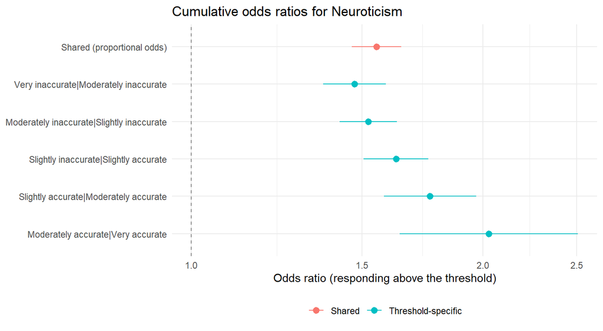

```r
nt <- ordinal::nominal_test(one_pred)

nt_lrt_value <- as.numeric(
  nt["neuroticism_c", "LRT"]
)

nt_p_value <- as.numeric(
  nt["neuroticism_c", "Pr(>Chi)"]
)
```

### 8.0.1 **Paragraph 1**

The outcome variable was C4, an ordinal item measuring agreement with the statement “Do things in a half-way manner,” and the predictor was Neuroticism, calculated as the mean of the five Neuroticism items and mean-centred before analysis. The analysis included 2774 participants. All six response categories were retained, with no categories collapsed. The least frequent category was “Very accurate” (*n* = 63). The likelihood ratio test indicated that adding Neuroticism significantly improved model fit compared with the null model, χ²(1) = 218.2, *p* = <2e-16. The ΔAIC (M1 − M0) was -216.2, indicating that the model including Neuroticism had a lower AIC. The cumulative odds ratio for Neuroticism was OR = 1.553, 95% CI [1.464, 1.648], *p* = <2e-16. An OR greater than one indicates that higher Neuroticism was associated with greater odds of selecting higher C4 response categories. Because C4 is reverse-keyed, higher response categories reflect greater agreement with doing things in a half-way manner and therefore lower Conscientiousness. However, this shared odds ratio should be interpreted cautiously because the proportional-odds assumption was not supported.